# Breast Classification Cancer Project - Simplistic Implementation

Mayank Dhami

30/08/2020

## 1. Intro

Hi, Kagglers!

This is my first project on Kaggle to learn data science.

This attempt might not be perfect, but certainly something to learn from.

Suggestions are welcomed for better techniques.

In short, I used few of the most well known algorithms to solve the purpose in this kernel. I hope data science beginners could learn a thing or few from this.

## 2. Data Importing and cleaning

### 2.1 Import dataset

cancer refers to the wbcd dataset in focus.

```r
cancer = read.csv("data/data.csv", stringsAsFactors = F)
str(cancer)
```

```
## 'data.frame':    569 obs. of  33 variables:
##  $ id                     : int  842302 842517 84300903 84348301 84358402 843786 844359 84458202 844981 84501001 ...
##  $ diagnosis              : chr  "M" "M" "M" "M" ...
##  $ radius_mean            : num  18 20.6 19.7 11.4 20.3 ...
##  $ texture_mean           : num  10.4 17.8 21.2 20.4 14.3 ...
##  $ perimeter_mean         : num  122.8 132.9 130 77.6 135.1 ...
##  $ area_mean              : num  1001 1326 1203 386 1297 ...
##  $ smoothness_mean        : num  0.1184 0.0847 0.1096 0.1425 0.1003 ...
##  $ compactness_mean       : num  0.2776 0.0786 0.1599 0.2839 0.1328 ...
##  $ concavity_mean         : num  0.3001 0.0869 0.1974 0.2414 0.198 ...
##  $ concave.points_mean    : num  0.1471 0.0702 0.1279 0.1052 0.1043 ...
##  $ symmetry_mean          : num  0.242 0.181 0.207 0.26 0.181 ...
##  $ fractal_dimension_mean : num  0.0787 0.0567 0.06 0.0974 0.0588 ...
##  $ radius_se              : num  1.095 0.543 0.746 0.496 0.757 ...
##  $ texture_se             : num  0.905 0.734 0.787 1.156 0.781 ...
```

[output cut: 19 more lines]

The last column ‘X’ does not have any meaningful values so it should be dropped.

### 2.2 Remove the last null column as identified earlier

```r
cancer = cancer[,-33]
```

### 2.3 Declare the target variable as categorical (factor).

```r
cancer$diagnosis = factor(cancer$diagnosis, levels = c("B", "M"), labels = c("Benign", "Malignant"))
```

### 2.4 Data format and summary of dataset

#### Data format

```r
str(cancer)
```

```
## 'data.frame':    569 obs. of  32 variables:
##  $ id                     : int  842302 842517 84300903 84348301 84358402 843786 844359 84458202 844981 84501001 ...
##  $ diagnosis              : Factor w/ 2 levels "Benign","Malignant": 2 2 2 2 2 2 2 2 2 2 ...
##  $ radius_mean            : num  18 20.6 19.7 11.4 20.3 ...
##  $ texture_mean           : num  10.4 17.8 21.2 20.4 14.3 ...
##  $ perimeter_mean         : num  122.8 132.9 130 77.6 135.1 ...
##  $ area_mean              : num  1001 1326 1203 386 1297 ...
##  $ smoothness_mean        : num  0.1184 0.0847 0.1096 0.1425 0.1003 ...
##  $ compactness_mean       : num  0.2776 0.0786 0.1599 0.2839 0.1328 ...
##  $ concavity_mean         : num  0.3001 0.0869 0.1974 0.2414 0.198 ...
##  $ concave.points_mean    : num  0.1471 0.0702 0.1279 0.1052 0.1043 ...
##  $ symmetry_mean          : num  0.242 0.181 0.207 0.26 0.181 ...
##  $ fractal_dimension_mean : num  0.0787 0.0567 0.06 0.0974 0.0588 ...
##  $ radius_se              : num  1.095 0.543 0.746 0.496 0.757 ...
##  $ texture_se             : num  0.905 0.734 0.787 1.156 0.781 ...
```

[output cut: 18 more lines]

#### Summary

```r
summary(cancer)
```

```
##        id                diagnosis    radius_mean      texture_mean
##  Min.   :     8670   Benign   :357   Min.   : 6.981   Min.   : 9.71
##  1st Qu.:   869218   Malignant:212   1st Qu.:11.700   1st Qu.:16.17
##  Median :   906024                   Median :13.370   Median :18.84
##  Mean   : 30371831                   Mean   :14.127   Mean   :19.29
##  3rd Qu.:  8813129                   3rd Qu.:15.780   3rd Qu.:21.80
##  Max.   :911320502                   Max.   :28.110   Max.   :39.28
##  perimeter_mean     area_mean      smoothness_mean   compactness_mean
##  Min.   : 43.79   Min.   : 143.5   Min.   :0.05263   Min.   :0.01938
##  1st Qu.: 75.17   1st Qu.: 420.3   1st Qu.:0.08637   1st Qu.:0.06492
##  Median : 86.24   Median : 551.1   Median :0.09587   Median :0.09263
##  Mean   : 91.97   Mean   : 654.9   Mean   :0.09636   Mean   :0.10434
##  3rd Qu.:104.10   3rd Qu.: 782.7   3rd Qu.:0.10530   3rd Qu.:0.13040
##  Max.   :188.50   Max.   :2501.0   Max.   :0.16340   Max.   :0.34540
##  concavity_mean    concave.points_mean symmetry_mean    fractal_dimension_mean
##  Min.   :0.00000   Min.   :0.00000     Min.   :0.1060   Min.   :0.04996
##  1st Qu.:0.02956   1st Qu.:0.02031     1st Qu.:0.1619   1st Qu.:0.05770
##  Median :0.06154   Median :0.03350     Median :0.1792   Median :0.06154
##  Mean   :0.08880   Mean   :0.04892     Mean   :0.1812   Mean   :0.06280
##  3rd Qu.:0.13070   3rd Qu.:0.07400     3rd Qu.:0.1957   3rd Qu.:0.06612
##  Max.   :0.42680   Max.   :0.20120     Max.   :0.3040   Max.   :0.09744
##    radius_se        texture_se      perimeter_se       area_se
##  Min.   :0.1115   Min.   :0.3602   Min.   : 0.757   Min.   :  6.802
##  1st Qu.:0.2324   1st Qu.:0.8339   1st Qu.: 1.606   1st Qu.: 17.850
##  Median :0.3242   Median :1.1080   Median : 2.287   Median : 24.530
##  Mean   :0.4052   Mean   :1.2169   Mean   : 2.866   Mean   : 40.337
##  3rd Qu.:0.4789   3rd Qu.:1.4740   3rd Qu.: 3.357   3rd Qu.: 45.190
##  Max.   :2.8730   Max.   :4.8850   Max.   :21.980   Max.   :542.200
##  smoothness_se      compactness_se      concavity_se     concave.points_se
##  Min.   :0.001713   Min.   :0.002252   Min.   :0.00000   Min.   :0.000000
##  1st Qu.:0.005169   1st Qu.:0.013080   1st Qu.:0.01509   1st Qu.:0.007638
##  Median :0.006380   Median :0.020450   Median :0.02589   Median :0.010930
##  Mean   :0.007041   Mean   :0.025478   Mean   :0.03189   Mean   :0.011796
##  3rd Qu.:0.008146   3rd Qu.:0.032450   3rd Qu.:0.04205   3rd Qu.:0.014710
##  Max.   :0.031130   Max.   :0.135400   Max.   :0.39600   Max.   :0.052790
##   symmetry_se       fractal_dimension_se  radius_worst   texture_worst
##  Min.   :0.007882   Min.   :0.0008948    Min.   : 7.93   Min.   :12.02
##  1st Qu.:0.015160   1st Qu.:0.0022480    1st Qu.:13.01   1st Qu.:21.08
##  Median :0.018730   Median :0.0031870    Median :14.97   Median :25.41
##  Mean   :0.020542   Mean   :0.0037949    Mean   :16.27   Mean   :25.68
##  3rd Qu.:0.023480   3rd Qu.:0.0045580    3rd Qu.:18.79   3rd Qu.:29.72
##  Max.   :0.078950   Max.   :0.0298400    Max.   :36.04   Max.   :49.54
##  perimeter_worst    area_worst     smoothness_worst  compactness_worst
##  Min.   : 50.41   Min.   : 185.2   Min.   :0.07117   Min.   :0.02729
##  1st Qu.: 84.11   1st Qu.: 515.3   1st Qu.:0.11660   1st Qu.:0.14720
##  Median : 97.66   Median : 686.5   Median :0.13130   Median :0.21190
##  Mean   :107.26   Mean   : 880.6   Mean   :0.13237   Mean   :0.25427
##  3rd Qu.:125.40   3rd Qu.:1084.0   3rd Qu.:0.14600   3rd Qu.:0.33910
##  Max.   :251.20   Max.   :4254.0   Max.   :0.22260   Max.   :1.05800
##  concavity_worst  concave.points_worst symmetry_worst   fractal_dimension_worst
##  Min.   :0.0000   Min.   :0.00000      Min.   :0.1565   Min.   :0.05504
##  1st Qu.:0.1145   1st Qu.:0.06493      1st Qu.:0.2504   1st Qu.:0.07146
##  Median :0.2267   Median :0.09993      Median :0.2822   Median :0.08004
##  Mean   :0.2722   Mean   :0.11461      Mean   :0.2901   Mean   :0.08395
##  3rd Qu.:0.3829   3rd Qu.:0.16140      3rd Qu.:0.3179   3rd Qu.:0.09208
##  Max.   :1.2520   Max.   :0.29100      Max.   :0.6638   Max.   :0.20750
```

#### Sample

```r
knitr::kable(head(cancer))
```

| id | diagnosis | radius_mean | texture_mean | perimeter_mean | area_mean | smoothness_mean | compactness_mean | concavity_mean | concave.points_mean | symmetry_mean | fractal_dimension_mean | radius_se | texture_se | perimeter_se | area_se | smoothness_se | compactness_se | concavity_se | concave.points_se | symmetry_se | fractal_dimension_se | radius_worst | texture_worst | perimeter_worst | area_worst | smoothness_worst | compactness_worst | concavity_worst | concave.points_worst | … |
| --- | --- | --- | --- | --- | --- | --- | --- | --- | --- | --- | --- | --- | --- | --- | --- | --- | --- | --- | --- | --- | --- | --- | --- | --- | --- | --- | --- | --- | --- | --- |
| 842302 | Malignant | 17.99 | 10.38 | 122.80 | 1001.0 | 0.11840 | 0.27760 | 0.3001 | 0.14710 | 0.2419 | 0.07871 | 1.0950 | 0.9053 | 8.589 | 153.40 | 0.006399 | 0.04904 | 0.05373 | 0.01587 | 0.03003 | 0.006193 | 25.38 | 17.33 | 184.60 | 2019.0 | 0.1622 | 0.6656 | 0.7119 | 0.2654 | … |
| 842517 | Malignant | 20.57 | 17.77 | 132.90 | 1326.0 | 0.08474 | 0.07864 | 0.0869 | 0.07017 | 0.1812 | 0.05667 | 0.5435 | 0.7339 | 3.398 | 74.08 | 0.005225 | 0.01308 | 0.01860 | 0.01340 | 0.01389 | 0.003532 | 24.99 | 23.41 | 158.80 | 1956.0 | 0.1238 | 0.1866 | 0.2416 | 0.1860 | … |
| 84300903 | Malignant | 19.69 | 21.25 | 130.00 | 1203.0 | 0.10960 | 0.15990 | 0.1974 | 0.12790 | 0.2069 | 0.05999 | 0.7456 | 0.7869 | 4.585 | 94.03 | 0.006150 | 0.04006 | 0.03832 | 0.02058 | 0.02250 | 0.004571 | 23.57 | 25.53 | 152.50 | 1709.0 | 0.1444 | 0.4245 | 0.4504 | 0.2430 | … |
| 84348301 | Malignant | 11.42 | 20.38 | 77.58 | 386.1 | 0.14250 | 0.28390 | 0.2414 | 0.10520 | 0.2597 | 0.09744 | 0.4956 | 1.1560 | 3.445 | 27.23 | 0.009110 | 0.07458 | 0.05661 | 0.01867 | 0.05963 | 0.009208 | 14.91 | 26.50 | 98.87 | 567.7 | 0.2098 | 0.8663 | 0.6869 | 0.2575 | … |
| 84358402 | Malignant | 20.29 | 14.34 | 135.10 | 1297.0 | 0.10030 | 0.13280 | 0.1980 | 0.10430 | 0.1809 | 0.05883 | 0.7572 | 0.7813 | 5.438 | 94.44 | 0.011490 | 0.02461 | 0.05688 | 0.01885 | 0.01756 | 0.005115 | 22.54 | 16.67 | 152.20 | 1575.0 | 0.1374 | 0.2050 | 0.4000 | 0.1625 | … |
| 843786 | Malignant | 12.45 | 15.70 | 82.57 | 477.1 | 0.12780 | 0.17000 | 0.1578 | 0.08089 | 0.2087 | 0.07613 | 0.3345 | 0.8902 | 2.217 | 27.19 | 0.007510 | 0.03345 | 0.03672 | 0.01137 | 0.02165 | 0.005082 | 15.47 | 23.75 | 103.40 | 741.6 | 0.1791 | 0.5249 | 0.5355 | 0.1741 | … |

As you can see, there are a lot of variables with very different range of values. Due to this, the impact of the larger valued variables will be more than the smaller ones. This could potentially cause problems in algorithms which calculate distance between instances like knn. So, there is a need to normalize the variable values.

### 2.5 Normalize data

```r
normalize = function(x){
  return((x-min(x))/(max(x)-min(x)))
}
cancer_n = as.data.frame(lapply(cancer[3:32], normalize))
cancer_n = cbind(cancer[,c(1,2)],cancer_n)
knitr::kable(head(cancer_n))
```

| id | diagnosis | radius_mean | texture_mean | perimeter_mean | area_mean | smoothness_mean | compactness_mean | concavity_mean | concave.points_mean | symmetry_mean | fractal_dimension_mean | radius_se | texture_se | perimeter_se | area_se | smoothness_se | compactness_se | concavity_se | concave.points_se | symmetry_se | fractal_dimension_se | radius_worst | texture_worst | perimeter_worst | area_worst | smoothness_worst | compactness_worst | concavity_worst | concave.points_worst | … |
| --- | --- | --- | --- | --- | --- | --- | --- | --- | --- | --- | --- | --- | --- | --- | --- | --- | --- | --- | --- | --- | --- | --- | --- | --- | --- | --- | --- | --- | --- | --- |
| 842302 | Malignant | 0.5210374 | 0.0226581 | 0.5459885 | 0.3637328 | 0.5937528 | 0.7920373 | 0.7031396 | 0.7311133 | 0.6863636 | 0.6055181 | 0.3561470 | 0.1204694 | 0.3690336 | 0.2738113 | 0.1592956 | 0.3513984 | 0.1356818 | 0.3006251 | 0.3116452 | 0.1830424 | 0.6207755 | 0.1415245 | 0.6683102 | 0.4506980 | 0.6011358 | 0.6192916 | 0.5686102 | 0.9120275 | … |
| 842517 | Malignant | 0.6431445 | 0.2725736 | 0.6157833 | 0.5015907 | 0.2898799 | 0.1817680 | 0.2036082 | 0.3487575 | 0.3797980 | 0.1413227 | 0.1564367 | 0.0825893 | 0.1244405 | 0.1256598 | 0.1193867 | 0.0813230 | 0.0469697 | 0.2538360 | 0.0845388 | 0.0911101 | 0.6069015 | 0.3035714 | 0.5398177 | 0.4352143 | 0.3475533 | 0.1545634 | 0.1929712 | 0.6391753 | … |
| 84300903 | Malignant | 0.6014956 | 0.3902604 | 0.5957432 | 0.4494168 | 0.5143089 | 0.4310165 | 0.4625117 | 0.6356859 | 0.5095960 | 0.2112468 | 0.2296216 | 0.0943025 | 0.1803704 | 0.1629218 | 0.1508312 | 0.2839547 | 0.0967677 | 0.3898466 | 0.2056903 | 0.1270055 | 0.5563856 | 0.3600746 | 0.5084417 | 0.3745085 | 0.4835898 | 0.3853751 | 0.3597444 | 0.8350515 | … |
| 84348301 | Malignant | 0.2100904 | 0.3608387 | 0.2335015 | 0.1029056 | 0.8113208 | 0.8113613 | 0.5656045 | 0.5228628 | 0.7762626 | 1.0000000 | 0.1390911 | 0.1758752 | 0.1266550 | 0.0381548 | 0.2514532 | 0.5432151 | 0.1429545 | 0.3536655 | 0.7281477 | 0.2872048 | 0.2483102 | 0.3859275 | 0.2413467 | 0.0940081 | 0.9154725 | 0.8140117 | 0.5486422 | 0.8848797 | … |
| 84358402 | Malignant | 0.6298926 | 0.1565776 | 0.6309861 | 0.4892895 | 0.4303512 | 0.3478928 | 0.4639175 | 0.5183897 | 0.3782828 | 0.1868155 | 0.2338222 | 0.0930649 | 0.2205626 | 0.1636876 | 0.3323588 | 0.1679184 | 0.1436364 | 0.3570752 | 0.1361794 | 0.1457996 | 0.5197439 | 0.1239339 | 0.5069476 | 0.3415749 | 0.4373638 | 0.1724151 | 0.3194888 | 0.5584192 | … |
| 843786 | Malignant | 0.2588386 | 0.2025702 | 0.2679842 | 0.1415058 | 0.6786133 | 0.4619962 | 0.3697282 | 0.4020378 | 0.5186869 | 0.5511794 | 0.0807532 | 0.1171322 | 0.0687933 | 0.0380801 | 0.1970629 | 0.2343107 | 0.0927273 | 0.2153817 | 0.1937299 | 0.1446596 | 0.2682319 | 0.3126333 | 0.2639076 | 0.1367479 | 0.7127386 | 0.4827837 | 0.4277157 | 0.5982818 | … |

## 3. Analyzing correlation between variables

### 3.1 Correlation among variables

However there are multiple packages to represent correlation, in this section I will use a standard version for all the variables (mean, se, worst).

#### Mean

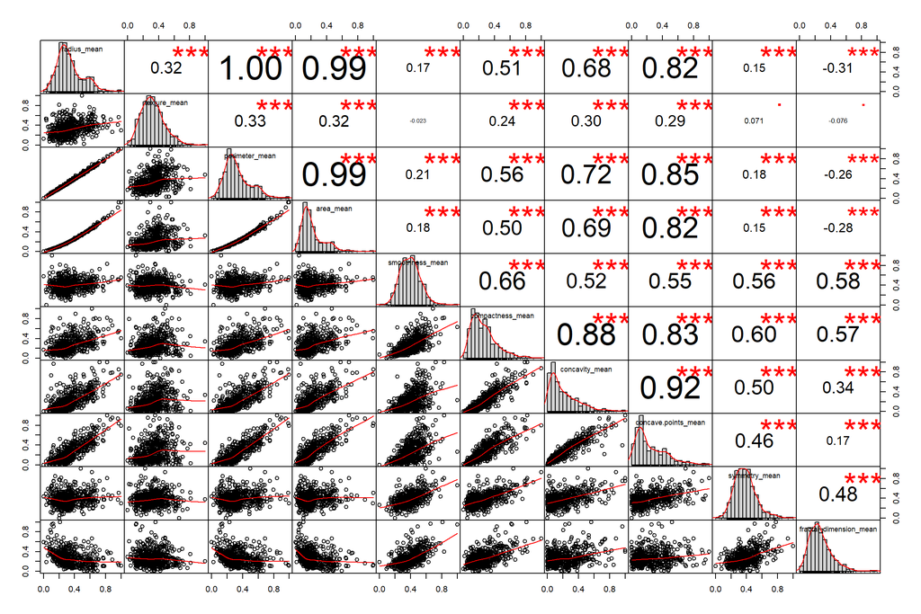

```r
library(PerformanceAnalytics)
chart.Correlation(cancer_n[,c(3:12)],histogram=TRUE, col="grey10", pch=1, main="Cancer Mean")
```

#### Standard Error

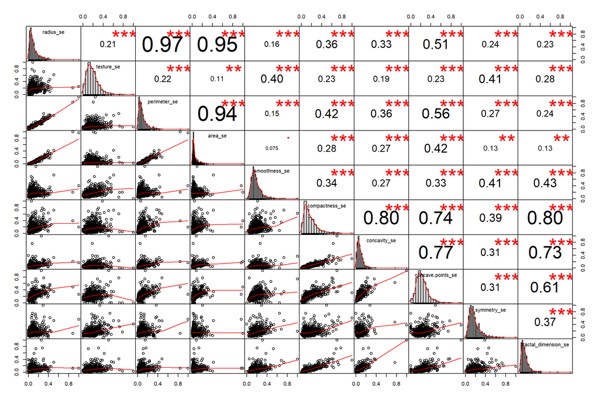

```r
chart.Correlation(cancer_n[,c(13:22)],histogram=TRUE, col="grey10", pch=1, main="Cancer SE")
```

#### Worst

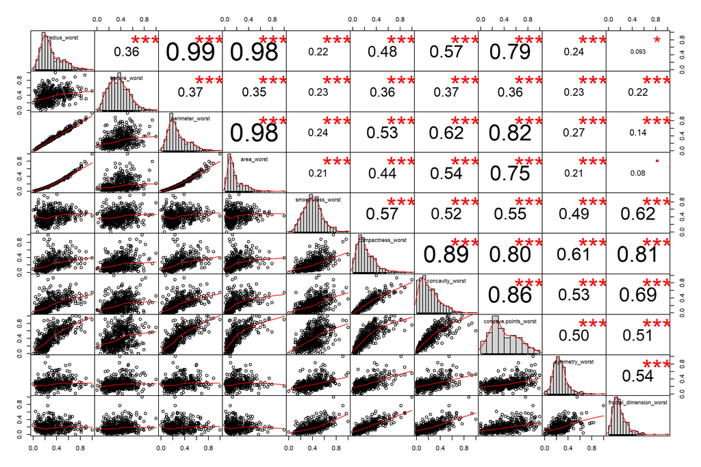

```r
chart.Correlation(cancer_n[,c(23:32)],histogram=TRUE, col="grey10", pch=1, main="Cancer Worst")
```

### 3.2 Using ggcorr for simplified plot

With color coding, it is easier to make out difference between correlation values.

#### Mean

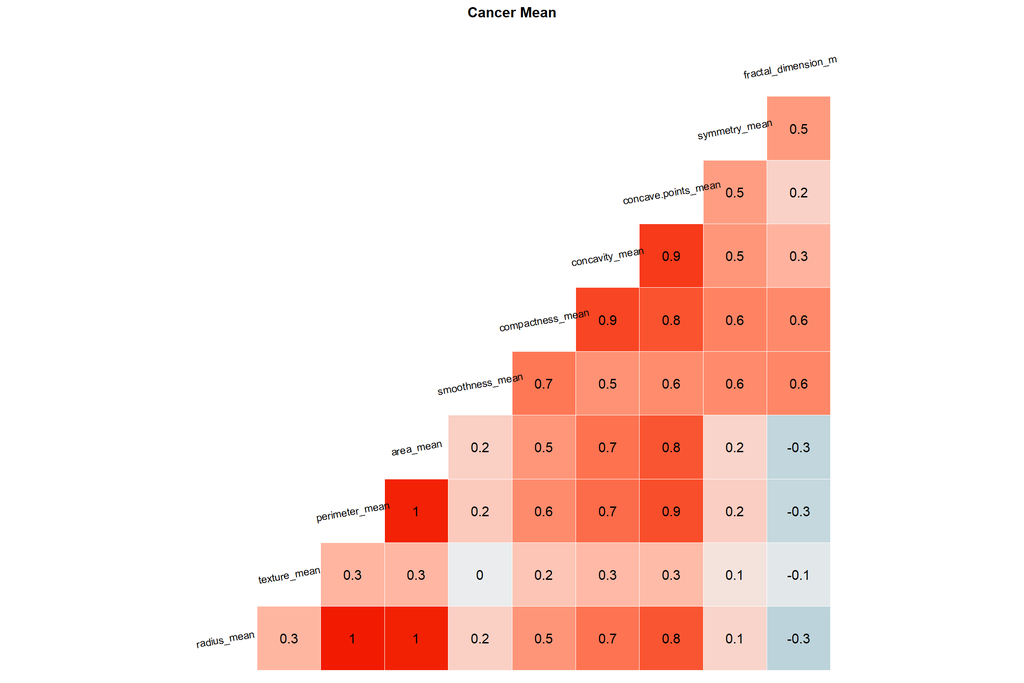

```r
library(GGally)
ggcorr(cancer_n[,c(3:12)], name = "corr", label = TRUE, size = 3, angle = 10)+
  theme(legend.position="none")+
labs(title="Cancer Mean")+
theme(plot.title=element_text(face='bold',color='black',hjust=0.5,size=12))
```

#### Standard Error

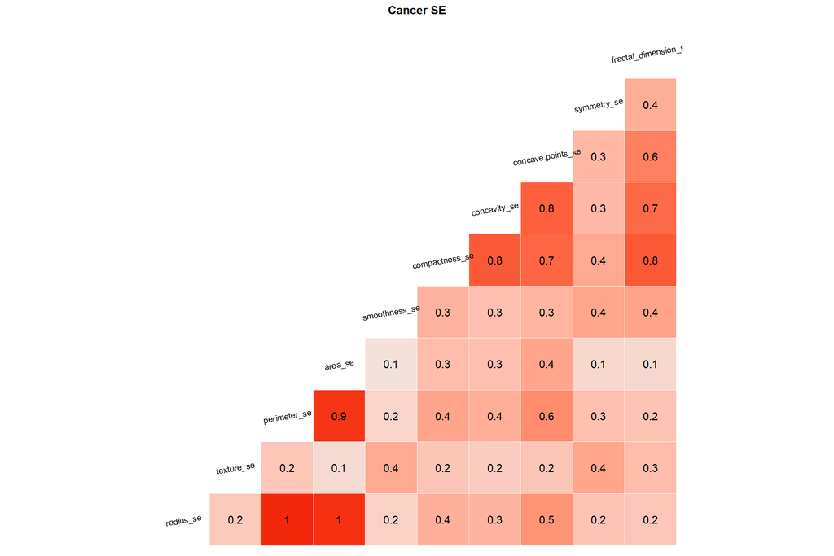

```r
ggcorr(cancer_n[,c(13:22)], name = "corr", label = TRUE, size = 3, angle = 10)+
  theme(legend.position="none")+
labs(title="Cancer SE")+
theme(plot.title=element_text(face='bold',color='black',hjust=0.5,size=12))
```

#### Worst

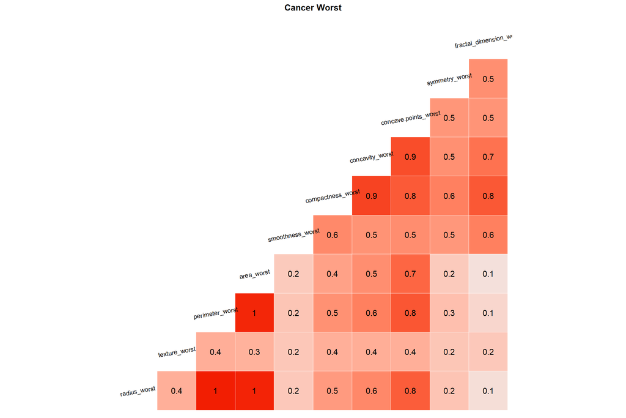

```r
ggcorr(cancer_n[,c(23:32)], name = "corr", label = TRUE, size = 3, angle = 10)+
  theme(legend.position="none")+
labs(title="Cancer Worst")+
theme(plot.title=element_text(face='bold',color='black',hjust=0.5,size=12))
```

## 4. Apply machine learning algorithms and compare them

### 4.1 Division of training and testing data

Randomly selecting 70% of the data for training and 30% for testing.

```r
set.seed(123)
library(dplyr)
library(caret)
cancer.survival <- cancer_n$diagnosis %>%
  createDataPartition(p = 0.70, list = FALSE)
cancer_train = cancer_n[cancer.survival,]
cancer_test = cancer_n[-cancer.survival,]
```

### 4.2 Sanity check proportion of benign and malignant cases in both datasets

#### train

```r
prop.table(table(cancer_train$diagnosis))
```

```
##
##    Benign Malignant
## 0.6265664 0.3734336
```

#### test

```r
prop.table(table(cancer_test$diagnosis))
```

```
##
##    Benign Malignant
## 0.6294118 0.3705882
```

They look pretty much very similar, so we are good to go.

### 4.3 Apply the most commonly used, high interpretability ML algorithms

#### CART (rpart)

```r
library(rpart)
cart = rpart(diagnosis~.,data=cancer_train[,-1], method = "class")
cart_pred = predict(cart, cancer_test[,c(-1,-2)], type="class")
cart_CM  = confusionMatrix(cart_pred, cancer_test$diagnosis)
cart_CM
```

```
## Confusion Matrix and Statistics
##
##            Reference
## Prediction  Benign Malignant
##   Benign       100         7
##   Malignant      7        56
##
##                Accuracy : 0.9176
##                  95% CI : (0.8657, 0.9542)
##     No Information Rate : 0.6294
##     P-Value [Acc > NIR] : <2e-16
##
##                   Kappa : 0.8235
##
##  Mcnemar's Test P-Value : 1
##
##             Sensitivity : 0.9346
##             Specificity : 0.8889
##          Pos Pred Value : 0.9346
##          Neg Pred Value : 0.8889
##              Prevalence : 0.6294
##          Detection Rate : 0.5882
##    Detection Prevalence : 0.6294
##       Balanced Accuracy : 0.9117
##
##        'Positive' Class : Benign
##
```

#### CART prune (rpart)

```r
library(rpart)
cart_prun = prune(cart, cp=cart$cptable[which.min(cart$cptable[,"xerror"]),"CP"])
cart_pred_prun = predict(cart_prun, cancer_test[,c(-1,-2)], type="class")
cart_CM_pru = confusionMatrix(cart_pred_prun, cancer_test$diagnosis)
cart_CM_pru
```

```
## Confusion Matrix and Statistics
##
##            Reference
## Prediction  Benign Malignant
##   Benign       100         7
##   Malignant      7        56
##
##                Accuracy : 0.9176
##                  95% CI : (0.8657, 0.9542)
##     No Information Rate : 0.6294
##     P-Value [Acc > NIR] : <2e-16
##
##                   Kappa : 0.8235
##
##  Mcnemar's Test P-Value : 1
##
##             Sensitivity : 0.9346
##             Specificity : 0.8889
##          Pos Pred Value : 0.9346
##          Neg Pred Value : 0.8889
##              Prevalence : 0.6294
##          Detection Rate : 0.5882
##    Detection Prevalence : 0.6294
##       Balanced Accuracy : 0.9117
##
##        'Positive' Class : Benign
##
```

#### C5.0

```r
library(C50)
c50 <- C5.0(cancer_train[,c(-1,-2)],cancer_train$diagnosis, trials =15)
c50_pred = predict(c50, cancer_test[,c(-1,-2)])
c50_CM = confusionMatrix(c50_pred, cancer_test$diagnosis)
c50_CM
```

```
## Confusion Matrix and Statistics
##
##            Reference
## Prediction  Benign Malignant
##   Benign       103         4
##   Malignant      4        59
##
##                Accuracy : 0.9529
##                  95% CI : (0.9094, 0.9795)
##     No Information Rate : 0.6294
##     P-Value [Acc > NIR] : <2e-16
##
##                   Kappa : 0.8991
##
##  Mcnemar's Test P-Value : 1
##
##             Sensitivity : 0.9626
##             Specificity : 0.9365
##          Pos Pred Value : 0.9626
##          Neg Pred Value : 0.9365
##              Prevalence : 0.6294
##          Detection Rate : 0.6059
##    Detection Prevalence : 0.6294
##       Balanced Accuracy : 0.9496
##
##        'Positive' Class : Benign
##
```

#### Random Forest

```r
library(randomForest)
rf = randomForest(diagnosis~.,cancer_train[,-1],importance = T)
rf_pred = predict(rf, cancer_test[,c(-1,-2)])
rf_CM = confusionMatrix(rf_pred,cancer_test$diagnosis)
rf_CM
```

```
## Confusion Matrix and Statistics
##
##            Reference
## Prediction  Benign Malignant
##   Benign       104         2
##   Malignant      3        61
##
##                Accuracy : 0.9706
##                  95% CI : (0.9327, 0.9904)
##     No Information Rate : 0.6294
##     P-Value [Acc > NIR] : <2e-16
##
##                   Kappa : 0.9372
##
##  Mcnemar's Test P-Value : 1
##
##             Sensitivity : 0.9720
##             Specificity : 0.9683
##          Pos Pred Value : 0.9811
##          Neg Pred Value : 0.9531
##              Prevalence : 0.6294
##          Detection Rate : 0.6118
##    Detection Prevalence : 0.6235
##       Balanced Accuracy : 0.9701
##
##        'Positive' Class : Benign
##
```

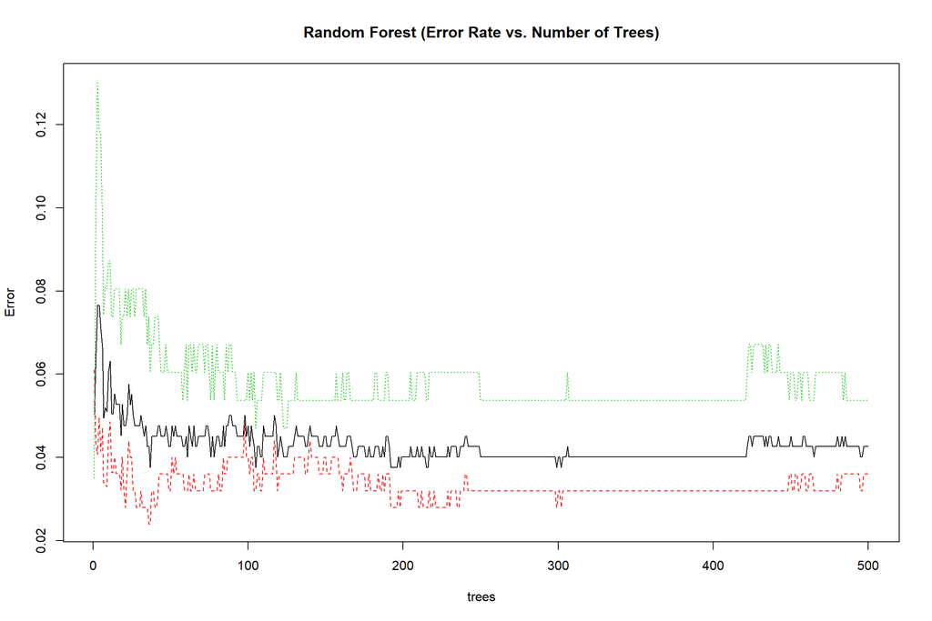

```r
plot(rf, main="Random Forest (Error Rate vs. Number of Trees)")
```

##### Variance Importance Plot

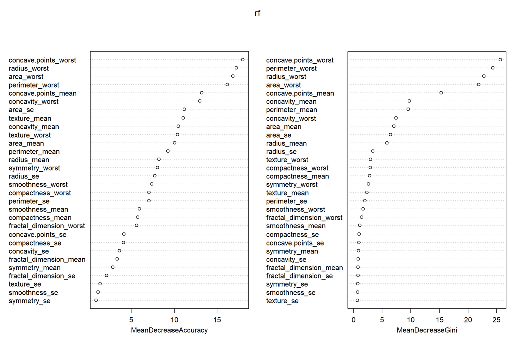

```r
varImpPlot(rf)
```

#### SVM

```r
library(e1071)
svmodel = svm(diagnosis~.,cancer_train[,-1], cost = 10)
svmpred = predict(svmodel,cancer_test[,c(-1,-2)])
svm_CM = confusionMatrix(svmpred,cancer_test$diagnosis)
svm_CM
```

```
## Confusion Matrix and Statistics
##
##            Reference
## Prediction  Benign Malignant
##   Benign       104         3
##   Malignant      3        60
##
##                Accuracy : 0.9647
##                  95% CI : (0.9248, 0.9869)
##     No Information Rate : 0.6294
##     P-Value [Acc > NIR] : <2e-16
##
##                   Kappa : 0.9243
##
##  Mcnemar's Test P-Value : 1
##
##             Sensitivity : 0.9720
##             Specificity : 0.9524
##          Pos Pred Value : 0.9720
##          Neg Pred Value : 0.9524
##              Prevalence : 0.6294
##          Detection Rate : 0.6118
##    Detection Prevalence : 0.6294
##       Balanced Accuracy : 0.9622
##
##        'Positive' Class : Benign
##
```

#### SVM Tuned

##### Choosing the gamma and cost parameters in SVM wich give best performance

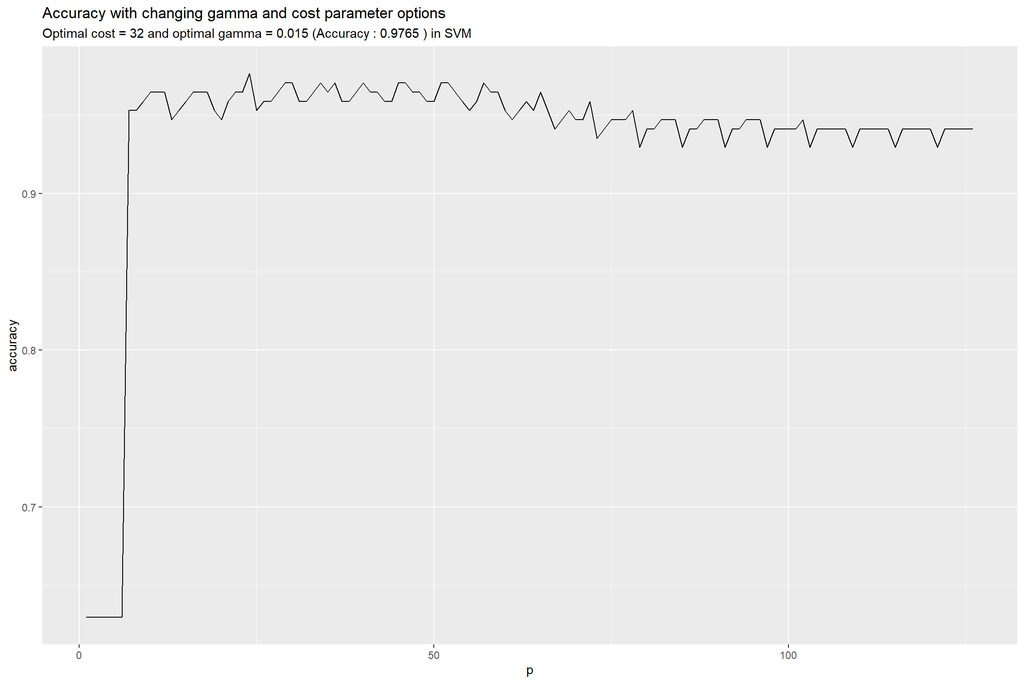

```r
library(e1071)
gamma = seq(0,0.1,0.005)
cost = 2^(0:5)
param = expand.grid(cost=cost, gamma=gamma)

acc = numeric()
acc1 = NULL; acc2 = NULL

for(i in 1:NROW(param)){
        svmodel2 = svm(diagnosis~., cancer_train[,-1], gamma=param$gamma[i], cost=param$cost[i])
        svm_pred2 = predict(svmodel2, cancer_test[,c(-1,-2)])
        acc1 = confusionMatrix(svm_pred2, cancer_test$diagnosis)
        acc2[i] = acc1$overall[1]
}

acc_list = data.frame(p= seq(1,NROW(param)), accuracy = acc2)

tune_p = subset(acc_list, accuracy==max(accuracy))[1,]
subs = paste("Optimal cost =", param$cost[tune_p$p],"and optimal gamma =", param$gamma[tune_p$p], "(Accuracy :", round(tune_p$accuracy,4),") in SVM")
library(ggplot2)
ggplot(acc_list, aes(x=p,y= accuracy)) +
geom_line()+labs(title = "Accuracy with changing gamma and cost parameter options", subtitle = subs)
```

##### Apply optimal parameters(gamma, cost) for best performance in SVM

```r
svm_tune = svm(diagnosis~., cancer_train[,-1], cost=param$cost[tune_p$p], gamma=param$gamma[tune_p$p])
svm_tunepred = predict(svm_tune, cancer_test[,c(-1,-2)])
svm_CMtune = confusionMatrix(svm_tunepred, cancer_test$diagnosis)
svm_CMtune
```

```
## Confusion Matrix and Statistics
##
##            Reference
## Prediction  Benign Malignant
##   Benign       105         2
##   Malignant      2        61
##
##                Accuracy : 0.9765
##                  95% CI : (0.9409, 0.9936)
##     No Information Rate : 0.6294
##     P-Value [Acc > NIR] : <2e-16
##
##                   Kappa : 0.9496
##
##  Mcnemar's Test P-Value : 1
##
##             Sensitivity : 0.9813
##             Specificity : 0.9683
##          Pos Pred Value : 0.9813
##          Neg Pred Value : 0.9683
##              Prevalence : 0.6294
##          Detection Rate : 0.6176
##    Detection Prevalence : 0.6294
##       Balanced Accuracy : 0.9748
##
##        'Positive' Class : Benign
##
```

#### Ada Boost

```r
library(ada)
adaml <- ada(diagnosis~., cancer_train[,-1], test.x = cancer_train[,c(-1,-2)], test.y = cancer_train[,2], type = "gentle", iter = 45)
ada_pred <- predict(adaml, cancer_test[,c(-1,-2)])
ada_CM <- confusionMatrix(ada_pred, cancer_test$diagnosis)
ada_CM
```

```
## Confusion Matrix and Statistics
##
##            Reference
## Prediction  Benign Malignant
##   Benign       106         3
##   Malignant      1        60
##
##                Accuracy : 0.9765
##                  95% CI : (0.9409, 0.9936)
##     No Information Rate : 0.6294
##     P-Value [Acc > NIR] : <2e-16
##
##                   Kappa : 0.9492
##
##  Mcnemar's Test P-Value : 0.6171
##
##             Sensitivity : 0.9907
##             Specificity : 0.9524
##          Pos Pred Value : 0.9725
##          Neg Pred Value : 0.9836
##              Prevalence : 0.6294
##          Detection Rate : 0.6235
##    Detection Prevalence : 0.6412
##       Balanced Accuracy : 0.9715
##
##        'Positive' Class : Benign
##
```

#### knn - Best tuned

##### k with best performance is chosen for model

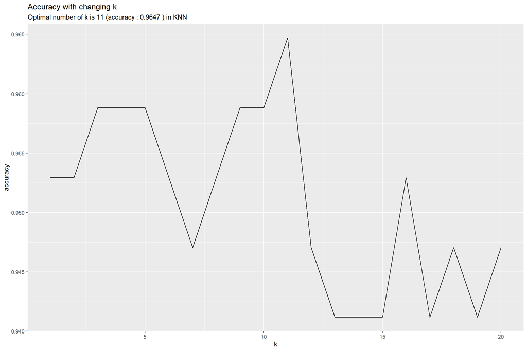

```r
library(class)
acc <- numeric()
for(i in 1:20){
    knn_pred = knn(cancer_train[,c(-1,-2)], cancer_test[,c(-1,-2)], cancer_train$diagnosis, k=i)
    acc = c(acc,mean(knn_pred==cancer_test$diagnosis))
}
acc = data.frame(k= seq(1,20), accuracy = acc)
tune_k = subset(acc, accuracy==max(accuracy))[1,]
subs = paste("Optimal number of k is", tune_k$k, "(accuracy :", round(tune_k$accuracy,4),") in KNN")
library(ggplot2)
ggplot(acc, aes(x=k,y= accuracy)) +
    geom_line()+labs(title = "Accuracy with changing k", subtitle = subs)
```

##### Apply optimal k for best prediction performance in KNN

```r
pred_knn = knn(cancer_train[,c(-1,-2)], cancer_test[,c(-1,-2)],cancer_train$diagnosis, k=tune_k$k)
knn_CM  = confusionMatrix(pred_knn, cancer_test$diagnosis)
knn_CM
```

```
## Confusion Matrix and Statistics
##
##            Reference
## Prediction  Benign Malignant
##   Benign       106         5
##   Malignant      1        58
##
##                Accuracy : 0.9647
##                  95% CI : (0.9248, 0.9869)
##     No Information Rate : 0.6294
##     P-Value [Acc > NIR] : <2e-16
##
##                   Kappa : 0.9233
##
##  Mcnemar's Test P-Value : 0.2207
##
##             Sensitivity : 0.9907
##             Specificity : 0.9206
##          Pos Pred Value : 0.9550
##          Neg Pred Value : 0.9831
##              Prevalence : 0.6294
##          Detection Rate : 0.6235
##    Detection Prevalence : 0.6529
##       Balanced Accuracy : 0.9556
##
##        'Positive' Class : Benign
##
```

### 4.4 Compare the models

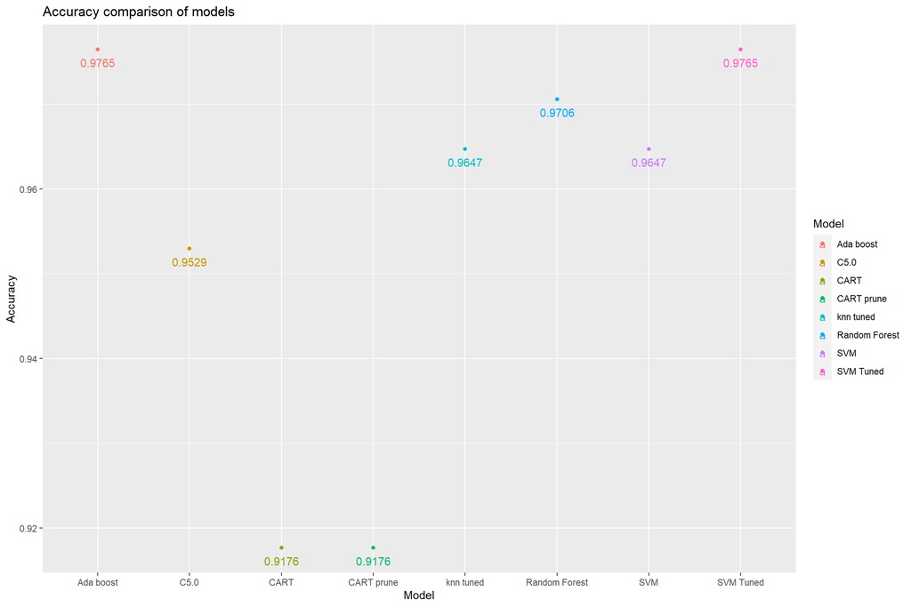

```r
model_cmp = data.frame(Model = c("CART","CART prune","C5.0","Random Forest","SVM","SVM Tuned", "Ada boost","knn tuned"), Accuracy = c(cart_CM$overall[1],cart_CM_pru$overall[1],c50_CM$overall[1],rf_CM$overall[1],svm_CM$overall[1],svm_CMtune$overall[1],ada_CM$overall[1],knn_CM$overall[1]))

library(ggplot2)
ggplot(model_cmp, aes(x=Model,y= Accuracy,color= Model, label= Accuracy)) +
    geom_point()+labs(title = "Accuracy comparison of models")+ geom_text(aes(label= round(Accuracy,4)),vjust=2)
```

Either of Adaboost and tuned SVM can be used for preparing the final prediction dataset.

## 5. Make final prediction dataset for submission

We are going to use tuned SVM predictions for submission.

```r
library(utils)
submit = data.frame(id = cancer_test[,1],predicted_status = svm_tunepred)
write.csv(submit,"submission.csv")
```

## 6. Conclusion

This was my first very simplistic version of wisconsin breast cancer dataset analysis and ML predictions. Tried to keep it as basic, yet informative.

Will come up with more detailed analysis and different algorithms next time hopefully. If you do find this worth a read and easily understandable, community upvotes and comments will encourage me to do better.

Thanks very much again!